# index_of_association.R

zhian

Fri May 1 19:28:06 2015

# Sliding window Index of Association

The index of assocation, developed by Brown, refined by Smith, and then standardized by Agapow and Burt, is a useful tool for detecting multilocus linkage disequilibrium, which can serve as an indication of clonal reproduction. Developed for a small number of markers, handling $\bar{r}_d$ for SNP data, which could have thousands of loci was not clear. Here, we will show calculation of the index of association utilizing sliding windows, detecting linkage between two or more loci per window.

```r
library("poppr")
```

The data. This comes from the adegenet package, a simulation of 100 individuals with 1,000 unstructured loci and 100 structured loci in strong LD.

```r
set.seed(999)
x <- glSim(100, 1e3, n.snp.struc=100, ploid=2, alpha = 0.1)
```

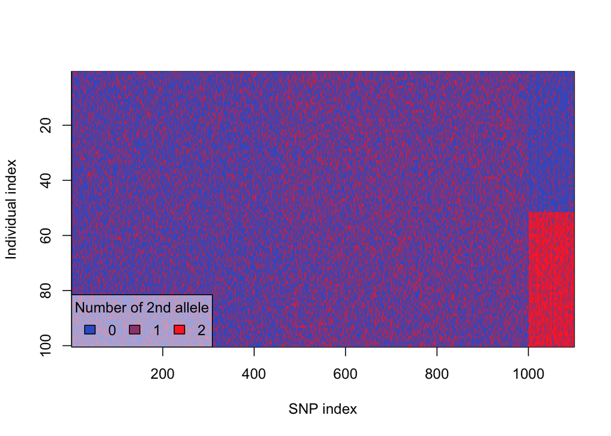

```r
y <- glSim(100, 1.1e3, ploid = 2) # random population
plot(x)
```

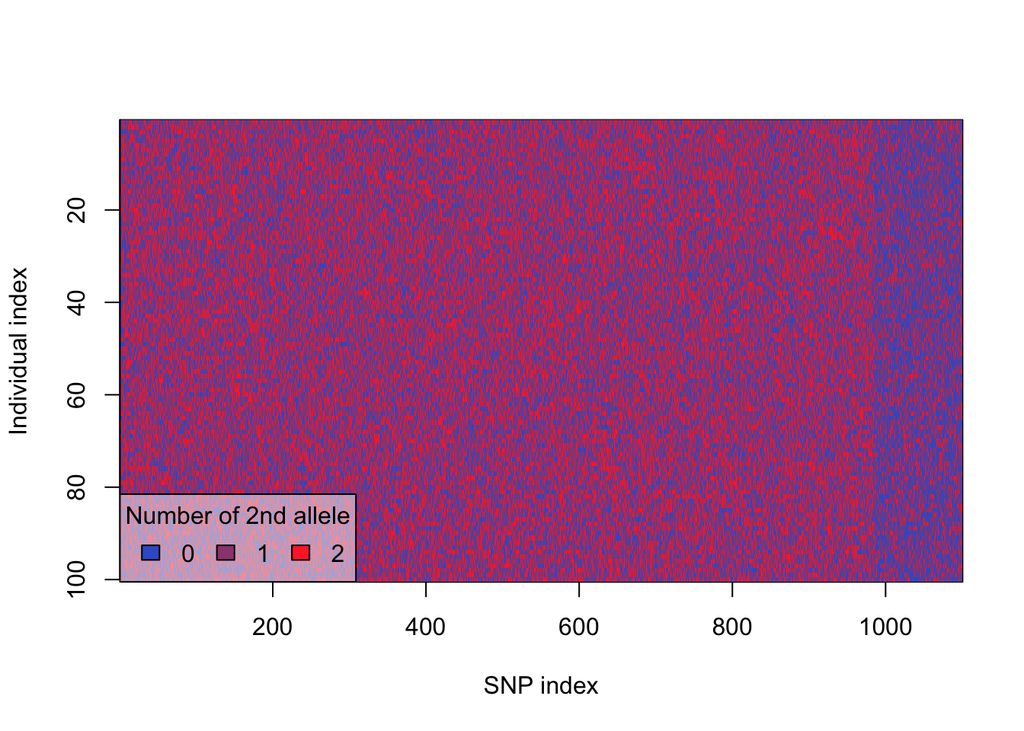

```r
plot(y)
```

If we use the windowing function for $\bar{r}_d$, here, we can see that all of the linkage is at the end of the data. First, we are going to set some arbitrary positions for the data.

```r
set.seed(999)
# I've wanted to do this type of assignment for a long time :)
position(x) <- sort(sample(1.1e4, 1.1e3)) -> position(y)
system.time(x.ia <- win.ia(x, quiet = TRUE)) # window size = 100
```

```
##    user  system elapsed
##  19.353   0.353  20.024
```

```r
system.time(y.ia <- win.ia(y, quiet = TRUE)) # window size = 100
```

```
##    user  system elapsed
##  18.193   0.247  18.696
```

Now we can visualize it

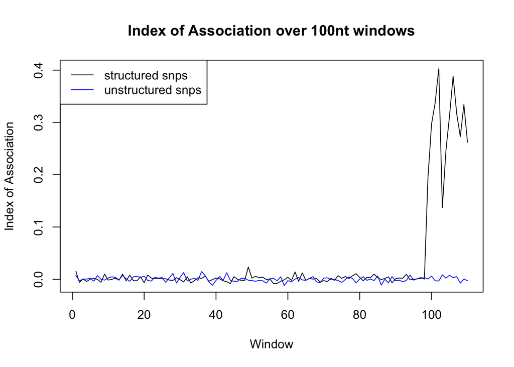

```r
plot(x.ia, type = "l", main = "Index of Association over 100nt windows",
     ylab = "Index of Association", xlab = "Window")
lines(y.ia, col = "blue")
legend("topleft", lty = 1, col = c("black", "blue"), legend = c("structured snps", "unstructured snps"))
```

Of course, with this strong LD, it’s pretty easy to detect a >100bp chunk. What happens if we randomly shuffle the loci?

```r
set.seed(999)
shuffled_loci <- sample(nLoc(x))
shuffled_inds <- sample(nInd(x))
x.shuff <- x[shuffled_inds, shuffled_loci]
y.shuff <- y[shuffled_inds, shuffled_loci]
position(x.shuff) <- position(x) -> position(y.shuff)# Reset the position
```

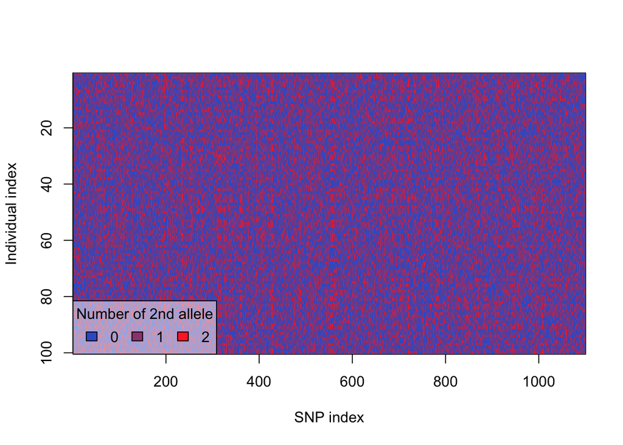

```r
plot(x.shuff)
```

```r
system.time(x.ia.shuff <- win.ia(x.shuff, quiet = TRUE))
```

```
##    user  system elapsed
##  19.752   0.237  22.023
```

```r
system.time(y.ia.shuff <- win.ia(y.shuff, quiet = TRUE))
```

```
##    user  system elapsed
##  20.468   0.340  22.370
```

Now we can plot it!

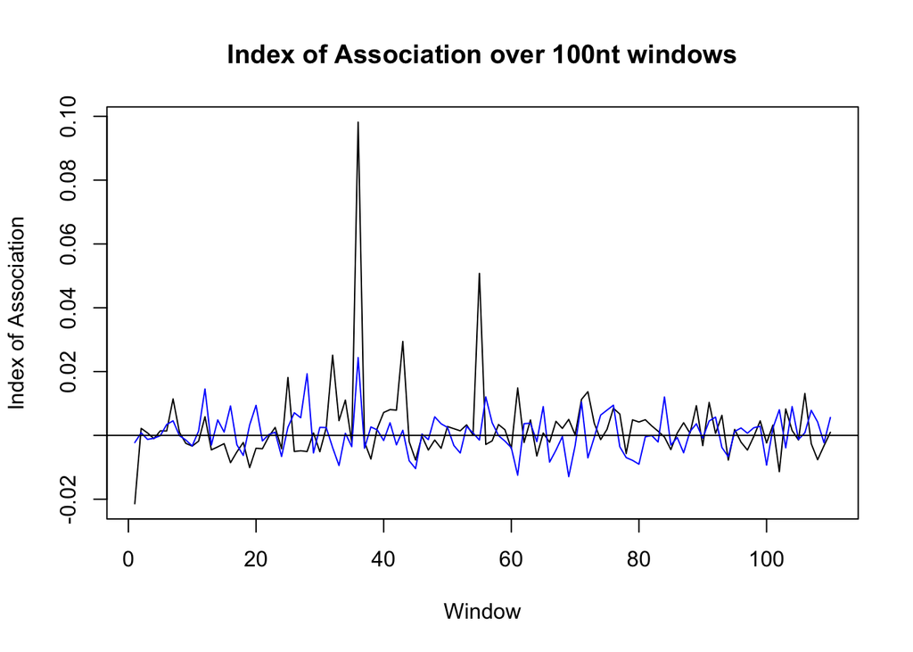

```r
plot(x.ia.shuff, type = "l", main = "Index of Association over 100nt windows",
     ylab = "Index of Association", xlab = "Window")
lines(y.ia.shuff, col = "blue")
abline(h = 0)
```

We can see exactly where the linked loci are by figuring out what windows they are in:

```r
nwin <- ceiling(max(position(x)/100L))
winmat <- matrix(100L * 1:nwin, nrow = nwin, ncol = 2)
winmat[, 1] <- winmat[, 1] - 100L + 1
linked <- position(x)[shuffled_loci > 1000]
link_wins <- unlist(sapply(linked,
                           function(x) which(x >= winmat[, 1] & x <= winmat[, 2])))
```

Now we can visualize this all together!

The vertical dashed lines represent windows that contain 3 or more structured SNPs, the thicker the lines, the greater the number of SNPs.

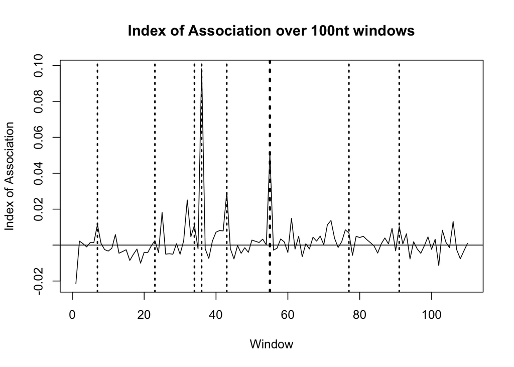

```r
plot(x.ia.shuff, type = "l", main = "Index of Association over 100nt windows",
     ylab = "Index of Association", xlab = "Window")
win_tab <- tabulate(link_wins)
which_wins <- win_tab >= 3
abline(v = which(which_wins), lty = 3, lwd = win_tab[which_wins] - 1)
abline(h = 0)
```

# Randomly sampling snps

Another method that can be done is to randomly sample SNPs to see if there is any structure. Here, we are sampling 50 snps 100 times.

```r
x.samp <- samp.ia(x, quiet = TRUE, n.snp = 50)
y.samp <- samp.ia(y, quiet = TRUE, n.snp = 50)
```

Now we can produce a boxplot

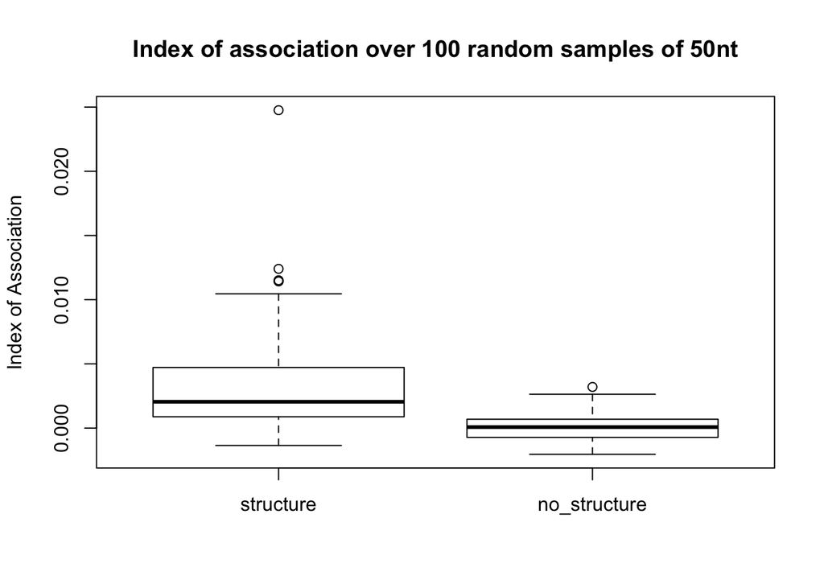

```r
boxplot(data.frame(structure = x.samp, no_structure = y.samp),
        ylab = "Index of Association",
        main = "Index of association over 100 random samples of 50nt")
```

# With clones

Now, we can compare populations with clones.

```r
source("my_functions.R")
```

We will simulate 1,100 neutral SNPs for 100 diploid samples. One population will be randomly sampled with replacement. For both populations, 5% of SNPs will then be randomly mutated and 1% missing data will be inserted.

```r
set.seed(20150501)
clone_samples <- getSims(n = 100, snps = 1.1e3, strucrat = 1, ploidy = 2,
                         na.perc = 0.01, err = 0.05, clone = TRUE, n.cores = 4)
set.seed(20150501)
sex_samples <- getSims(n = 100, snps = 1.1e3, strucrat = 1, ploidy = 2,
                       na.perc = 0.01,  err = 0.05, clone = FALSE, n.cores = 4)
```

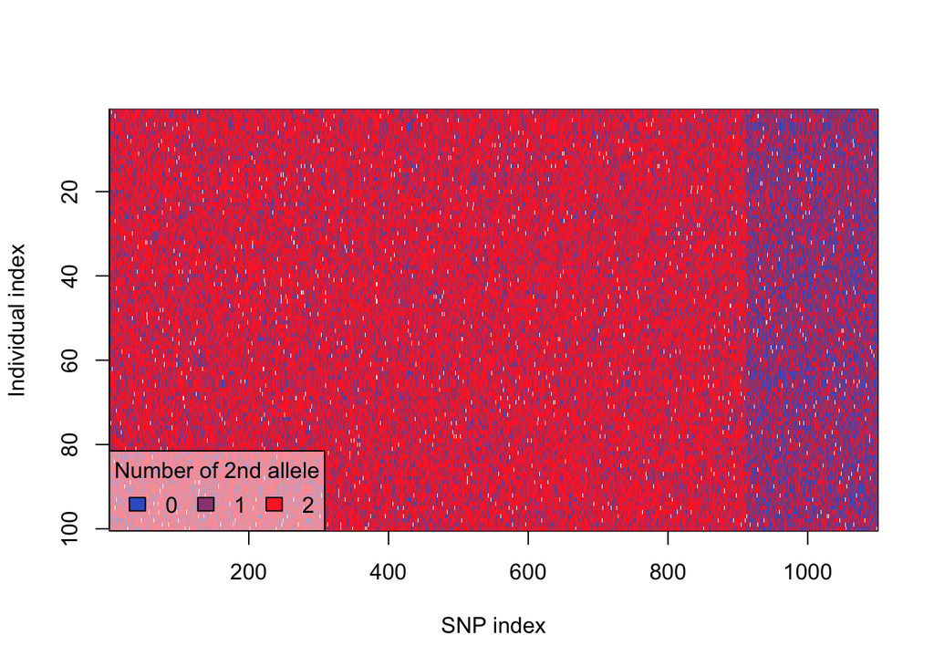

```r
position(clone_samples) <- position(x) -> position(sex_samples)
plot(clone_samples)
```

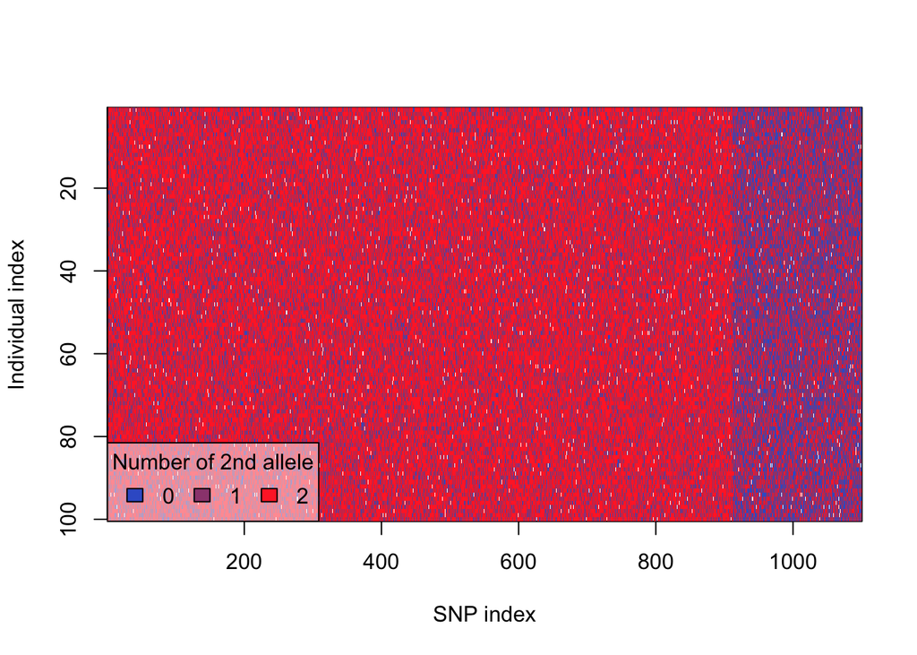

```r
plot(sex_samples)
```

```r
# 100nt windows
system.time(clone.ia <- win.ia(clone_samples, quiet = TRUE))
```

```
##    user  system elapsed
##  18.651   0.198  19.099
```

```r
system.time(sex.ia <- win.ia(sex_samples, quiet = TRUE))
```

```
##    user  system elapsed
##  18.220   0.141  18.532
```

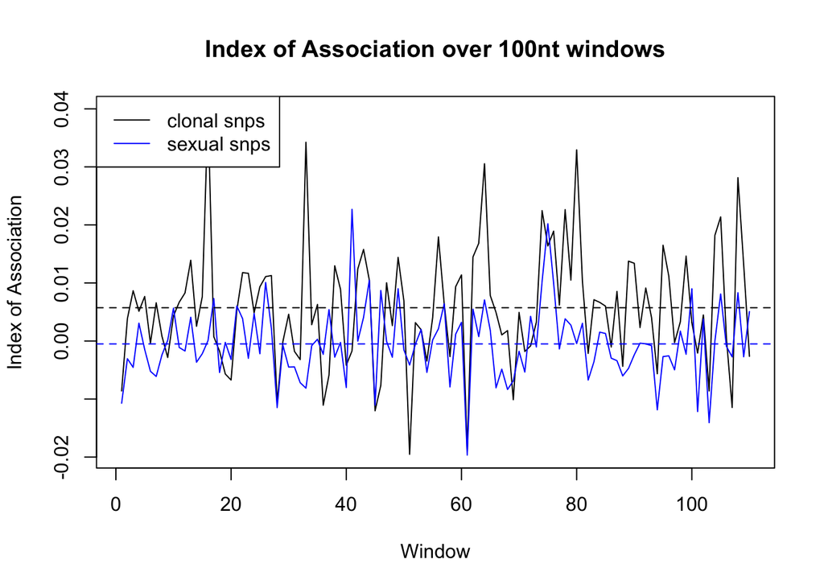

```r
plot(clone.ia, type = "l", main = "Index of Association over 100nt windows",
     ylab = "Index of Association", xlab = "Window")
lines(sex.ia, col = "blue")
legend("topleft", lty = 1, col = c("black", "blue"), legend = c("clonal snps", "sexual snps"))
abline(h = mean(clone.ia), lty = 2)
abline(h = mean(sex.ia), lty = 2, col = "blue")
```

```r
# 100nt windows
system.time(clone.ia1k <- win.ia(clone_samples, quiet = TRUE, window = 5e2, threads = 2))
```

```
##    user  system elapsed
##  17.860   2.378  19.650
```

```r
system.time(sex.ia1k <- win.ia(sex_samples, quiet = TRUE, window = 5e2, threads = 2))
```

```
##    user  system elapsed
##  17.762   2.328  19.506
```

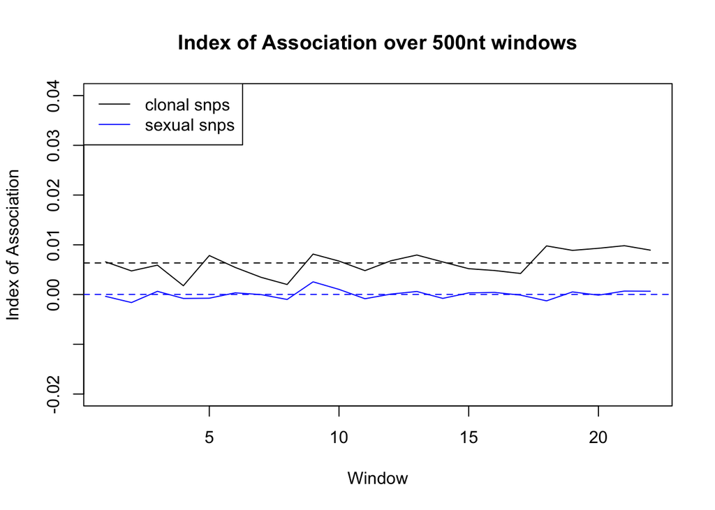

```r
plot(clone.ia1k, type = "l", main = "Index of Association over 500nt windows",
     ylab = "Index of Association", xlab = "Window",
     ylim = c(-0.02, 0.04))
lines(sex.ia1k, col = "blue")
legend("topleft", lty = 1, col = c("black", "blue"), legend = c("clonal snps", "sexual snps"))
abline(h = mean(clone.ia1k), lty = 2)
abline(h = mean(sex.ia1k), lty = 2, col = "blue")
```

Now, to do boxplots

```r
set.seed(20150501) #
system.time(clone.samp <- samp.ia(clone_samples, quiet = TRUE, n.snp = 50))
```

```
##    user  system elapsed
##  81.583   0.592  84.382
```

```r
set.seed(20150501) #
system.time(sex.samp <- samp.ia(sex_samples, quiet = TRUE, n.snp = 50))
```

```
##    user  system elapsed
##  80.931   0.692  82.708
```

Now we can produce a boxplot

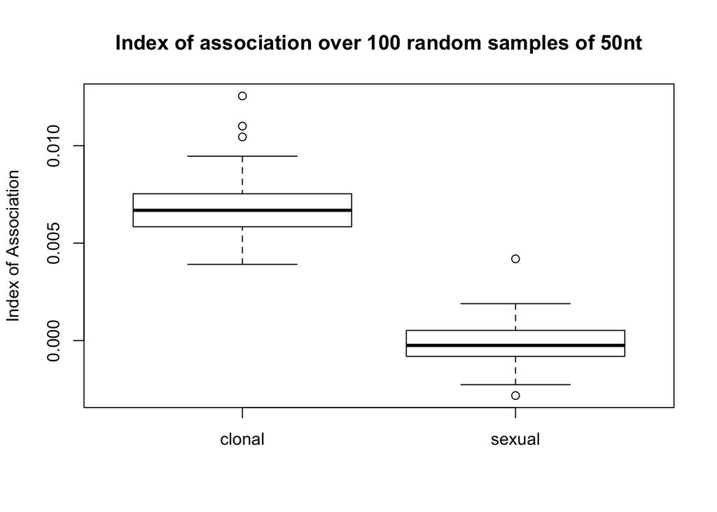

```r
boxplot(data.frame(clonal = clone.samp, sexual = sex.samp),
        ylab = "Index of Association",
        main = "Index of association over 100 random samples of 50nt")
```

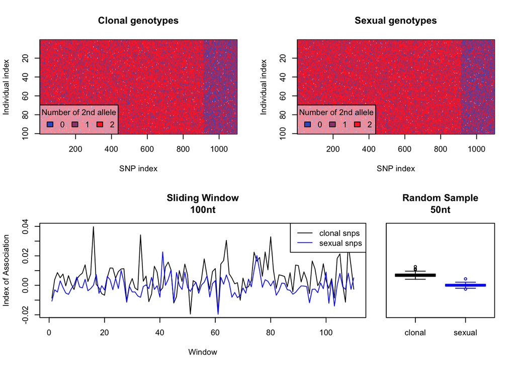

```r
par(mar = c(5, 4, 4, 2) + 0.1)
lay <- layout(matrix(c(1, 1, 2, 2, 3, 3, 3, 4), nrow = 2, byrow = TRUE))
glPlot(clone_samples, main = "Clonal genotypes")
glPlot(sex_samples, main = "Sexual genotypes", yaxt = "n")
plot(clone.ia, type = "l", main = "Sliding Window\n100nt",
     ylab = "Index of Association", xlab = "Window")
lines(sex.ia, col = "blue")
legend("topright", lty = 1, col = c("black", "blue"), legend = c("clonal snps", "sexual snps"))
# abline(h = mean(clone.ia), lty = 2)
# abline(h = mean(sex.ia), lty = 2, col = "blue")
par(mar = c(5.1, 0, 4.1, 2.1))
boxplot(data.frame(clonal = clone.samp, sexual = sex.samp), ylim = c(-0.02, 0.04), ylab = NA, yaxt = "n", border = c("black", "blue"),
        main = "Random Sample\n50nt")
```

```r
par(mar = c(5, 4, 4, 2) + 0.1)
layout(matrix(1))
```

```r
dput(clone.ia1k)
```

```
## c(0.00657391971000822, 0.00475038591717665, 0.00590697833268689,
## 0.00177109538039166, 0.00784047946321868, 0.0054449176789628,
## 0.0034546641854964, 0.00201826415448331, 0.00813373673459406,
## 0.00672417961410611, 0.00480721235398328, 0.00678500928464932,
## 0.00794412919608892, 0.00655265902625263, 0.00519412099605239,
## 0.00482666549041363, 0.00423481235959196, 0.00977692824280489,
## 0.00887914416454708, 0.00929758009021998, 0.00982107516784088,
## 0.00892714984879962)
```

```r
dput(sex.ia1k)
```

```
## c(-0.00036111463745087, -0.00161082157856051, 0.000646301300361051,
## -0.000783599448513505, -0.000737780755565264, 0.000345913597362971,
## -1.43896254450503e-05, -0.000989197741085604, 0.00255348821129859,
## 0.00103618415132276, -0.000842900319607663, 9.24300295566038e-05,
## 0.000615350863052257, -0.00077139583620435, 0.00032983201971487,
## 0.000427158402985452, -0.000117896610909437, -0.00126718088379165,
## 0.000529034858988589, -0.00012689674046699, 0.000696255806013379,
## 0.000663363086076998)
```

```r
dput(clone.samp)
```

[output not shown]

```r
dput(sex.samp)
```

[output not shown]

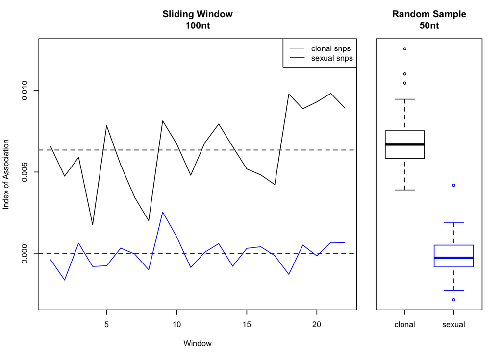

```r
par(mar = c(5, 4, 4, 2) + 0.1)
ylims <- range(sex.ia1k, clone.ia1k, clone.samp, sex.samp)
lay <- layout(matrix(c(1, 1, 1, 2), nrow = 1, byrow = TRUE))
plot(clone.ia1k, type = "l", main = "Sliding Window\n100nt",
     ylab = "Index of Association", xlab = "Window", ylim = ylims)
lines(sex.ia1k, col = "blue")
abline(h = mean(clone.ia1k), lty = 2)
abline(h = mean(sex.ia1k), lty = 2, col = "blue")
legend("topright", lty = 1, col = c("black", "blue"), legend = c("clonal snps", "sexual snps"))
par(mar = c(5.1, 0, 4.1, 2.1))
boxplot(data.frame(clonal = clone.samp, sexual = sex.samp), ylim = ylims, ylab = NA, yaxt = "n", border = c("black", "blue"),
        main = "Random Sample\n50nt")
```

```r
par(mar = c(5, 4, 4, 2) + 0.1)
layout(matrix(1))
```

## Session Info

```r
options(width = 100)
```

```
##  setting  value
##  version  R version 3.2.0 (2015-04-16)
##  system   x86_64, darwin13.4.0
##  ui       X11
##  language (EN)
##  collate  en_US.UTF-8
##  tz       America/Los_Angeles
```

```
## Packages -------------------------------------------------------------------------------------------
```

```
##  package    * version      date       source
##  ade4         1.7-2        2015-04-14 CRAN (R 3.2.0)
##  adegenet     2.0.0        2015-05-01 Github (thibautjombart/adegenet@9da1f25)
##  ape        * 3.2          2014-12-05 CRAN (R 3.2.0)
##  assertthat * 0.1          2013-12-06 CRAN (R 3.1.0)
##  boot       * 1.3-16       2015-03-08 CRAN (R 3.2.0)
##  cluster    * 2.0.1        2015-01-31 CRAN (R 3.1.2)
##  coda       * 0.17-1       2015-03-03 CRAN (R 3.2.0)
##  colorspace * 1.2-6        2015-03-11 CRAN (R 3.2.0)
##  DBI        * 0.3.1        2014-09-24 CRAN (R 3.1.1)
##  deldir     * 0.1-9        2015-03-09 CRAN (R 3.2.0)
##  devtools   * 1.7.0        2015-01-17 CRAN (R 3.2.0)
##  digest     * 0.6.8        2014-12-31 CRAN (R 3.1.2)
##  dplyr      * 0.4.1        2015-01-14 CRAN (R 3.1.2)
##  evaluate   * 0.6          2015-04-13 CRAN (R 3.2.0)
##  formatR    * 1.1          2015-03-29 CRAN (R 3.2.0)
##  ggplot2    * 1.0.1        2015-03-17 CRAN (R 3.2.0)
##  gtable     * 0.1.2        2012-12-05 CRAN (R 3.1.0)
##  htmltools  * 0.2.6        2014-09-08 CRAN (R 3.1.1)
##  httpuv     * 1.3.2        2014-10-23 CRAN (R 3.1.2)
##  igraph     * 0.7.1        2014-04-22 CRAN (R 3.1.0)
##  knitr      * 1.10         2015-04-23 CRAN (R 3.2.0)
##  lattice    * 0.20-31      2015-03-30 CRAN (R 3.2.0)
##  LearnBayes * 2.15         2014-05-29 CRAN (R 3.1.0)
##  magrittr   * 1.5          2014-11-22 CRAN (R 3.1.2)
##  MASS       * 7.3-40       2015-03-21 CRAN (R 3.2.0)
##  Matrix     * 1.2-0        2015-04-04 CRAN (R 3.2.0)
##  mgcv       * 1.8-6        2015-03-31 CRAN (R 3.2.0)
##  mime       * 0.3          2015-03-29 CRAN (R 3.1.3)
##  munsell    * 0.4.2        2013-07-11 CRAN (R 3.1.0)
##  nlme       * 3.1-120      2015-02-20 CRAN (R 3.2.0)
##  nnls       * 1.4          2012-03-19 CRAN (R 3.1.2)
##  pegas      * 0.7-0.4      2015-04-30 Github (emmanuelparadis/pegas@883d74f)
##  permute    * 0.8-3        2014-01-29 CRAN (R 3.1.0)
##  phangorn   * 1.99-14      2015-04-30 Github (KlausVigo/phangorn@7e97281)
##  plyr       * 1.8.1        2014-02-26 CRAN (R 3.1.0)
##  poppr        1.1.4.99-395 2015-05-01 Github (grunwaldlab/poppr@f955c52)
##  proto      * 0.3-10       2012-12-22 CRAN (R 3.1.0)
##  R6         * 2.0.1        2014-10-29 CRAN (R 3.1.2)
##  Rcpp       * 0.11.5       2015-03-06 CRAN (R 3.2.0)
##  reshape2   * 1.4.1        2014-12-06 CRAN (R 3.1.2)
##  rmarkdown  * 0.5.1        2015-01-26 CRAN (R 3.2.0)
##  rstudioapi * 0.3.1        2015-04-07 CRAN (R 3.2.0)
##  scales     * 0.2.4        2014-04-22 CRAN (R 3.1.0)
##  seqinr     * 3.1-3        2014-12-17 CRAN (R 3.1.2)
##  shiny      * 0.11.1.9004  2015-04-16 Github (rstudio/shiny@02caf05)
##  sp         * 1.0-17       2015-01-08 CRAN (R 3.1.2)
##  spdep      * 0.5-88       2015-03-17 CRAN (R 3.2.0)
##  stringr    * 0.6.2        2012-12-06 CRAN (R 3.1.0)
##  vegan      * 2.2-1        2015-01-12 CRAN (R 3.1.2)
##  xtable     * 1.7-4        2014-09-12 CRAN (R 3.1.1)
```